# 世界銀行のオープンデータによる平均寿命・出生率の可視化

世界，南アメリカ州の例

[岩田真一郎](https://shinichiro-iwata.github.io/)（ [神奈川大学経済学部](https://www.econ.kanagawa-u.ac.jp/)）

2022-08-15作成，2025-03-02改訂

# 目的

世界銀行のオープンデータサイト（[World Bank Open Data](https://data.worldbank.org/)）には世界各国の経済，気候変動貧困，健康，教育，ジェンダーなどに関する約8000の開発指標が無料公開されている．ここでは，[Natural Earth](https://www.naturalearthdata.com/)の世界地図に世界銀行の指標（平均寿命と出生率）を表現する．

- 世界銀行のオープンデータを扱うパッケージが用意されているため，それを利用する．
  - パッケージをインストールする場合は`install.packages("WDI")`．

パッケージ：`sf`，`tidyverse`，`rnaturalearth`，`WDI`

```r
library(sf)
library(tidyverse)

#Natural Earth
library(rnaturalearth)
#WDI
library(WDI)
```

# 平均寿命

**世界地図の読込**

詳細は[Natural Earthの地理空間データの可視化](https://shinichiro-iwata.github.io/geospatial-data-visualization/rnaturalearth-visualization.html)参照．

```r
World_map <-
  ne_countries(scale="medium")
```

**指標の選択とデータフレームの作成**

`R`パッケージを利用しているため，指標そのものをダウンロードする必要はない．ただし，指標名が分からないと，指標を可視できない．そこで，次のように世界銀行のオープンデータサイトから指標名を探す．

- [World Bank Open Data](https://data.worldbank.org/) > [Indicators](https://data.worldbank.org/indicator)（Browse by Country or Indicatorの**Indicator**をクリック） > （例えば，スクロールして指標を探す）Life expectancy at birth, total (years)
  - Life expectancy at birth, total (years)をクリックすると，この指標の詳細を説明するサイトに移動する．このサイトのURLに指標名が現れるため，これをコピーする．
  - 今回の場合，[https://data.worldbank.org/indicator/SP.DYN.LE00.IN?view=chart]であるが，`？`の前の`SP.DYN.LE00.IN`をコピーする．
  - YouTube → [How to Download World Bank Data in R-Studio](https://www.youtube.com/watch?v=R9qw_k94wK0)（アクセス日：2022-08-15）を参照．
- データフレームを作成する．`Life_expectancy`と名付ける．
  - `WDI()`を利用．指標（`indicator`）として`SP.DYN.LE00.IN`を利用することを指示．
  - `extra=TRUE`のオプションを付けることで，その他の情報もデータフレームに加わる．オプションを付けない場合，最小限の情報．
  - 指標は時系列に整備されている．ここでは，`2020`のみを使用することにする．そのために，最初（`start`）と終わり（`end`）の西暦を指示．
  - 指標名を分かり易く変更．

```r
#使用する指標
Life_expectancy <-
  WDI(indicator="SP.DYN.LE00.IN", extra=TRUE,
      start=2020, end=2020)

#列名の変更
Life_expectancy %>%
  rename(life_ex=SP.DYN.LE00.IN) ->
  Life_expectancy
```

**データの中身**

```r
#最初の6行
Life_expectancy %>%
  head()
```

|  | country | iso2c | iso3c | year | life_ex | status | lastupdated | region | capital | longitude | latitude | income | lending |
| --- | --- | --- | --- | --- | --- | --- | --- | --- | --- | --- | --- | --- | --- |
| 1 | Afghanistan | AF | AFG | 2020 | 62.57500 |  | 2025-01-28 | South Asia | Kabul | 69.1761 | 34.5228 | Low income | IDA |
| 2 | Africa Eastern and Southern | ZH | AFE | 2020 | 63.30979 |  | 2025-01-28 | Aggregates |  |  |  | Aggregates | Aggregates |
| 3 | Africa Western and Central | ZI | AFW | 2020 | 57.18067 |  | 2025-01-28 | Aggregates |  |  |  | Aggregates | Aggregates |
| 4 | Albania | AL | ALB | 2020 | 76.98900 |  | 2025-01-28 | Europe & Central Asia | Tirane | 19.8172 | 41.3317 | Upper middle income | IBRD |
| 5 | Algeria | DZ | DZA | 2020 | 74.45300 |  | 2025-01-28 | Middle East & North Africa | Algiers | 3.05097 | 36.7397 | Lower middle income | IBRD |
| 6 | American Samoa | AS | ASM | 2020 | NA |  | 2025-01-28 | East Asia & Pacific | Pago Pago | -170.691 | -14.2846 | Upper middle income | Not classified |

**データの結合**

世界地図（`World_map`）と平均寿命データ（`Life_expectancy`）を結合．

```r
Life_ex_map <-
  left_join(World_map, Life_expectancy,
            by=c("iso_a3"="iso3c"))
```

**完成図形**

完成図からは南極大陸（`ATA`）を削除する（好み）．

```r
#南極大陸削除
Life_ex_map %>%
  filter(iso_a3!="ATA") ->
  Life_ex_map
```

- 色分けは平均寿命であることを指示（`aes(fill=life_ex)`）．
- 各国の枠（`color`）は白（`white`）に指示．
- 凡例を図の下に移動（`legend.position="bottom"`）．
- 出典を地図の隅に示す（`caption`）．
- ロビンソン図法（`ESRI:54030`）．

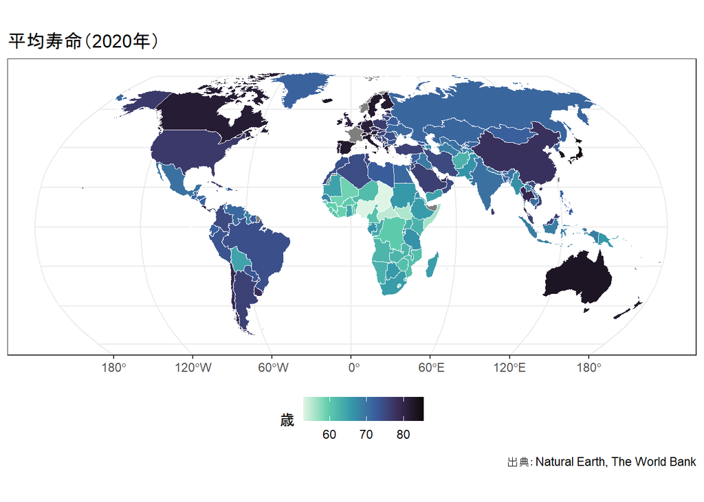

```r
ggplot()+
  geom_sf(data=Life_ex_map, aes(fill=life_ex),
          color="white")+
  scale_fill_viridis_c(option="G", direction=-1)+
  labs(fill="歳",
       caption="出典：Natural Earth, The World Bank")+
  ggtitle("平均寿命（2020年）")+
  coord_sf(crs=st_crs("ESRI:54030"))+
  theme_bw()+
  theme(legend.position="bottom")
```

# 出生率

同様にして，出生率を可視化．

- 出生率の指標はFertility rate, total (births per woman)で指標名は`SP.DYN.TFRT.IN`．
  - ここでも2020年を利用．
  - コードは繰り返しのため省略．

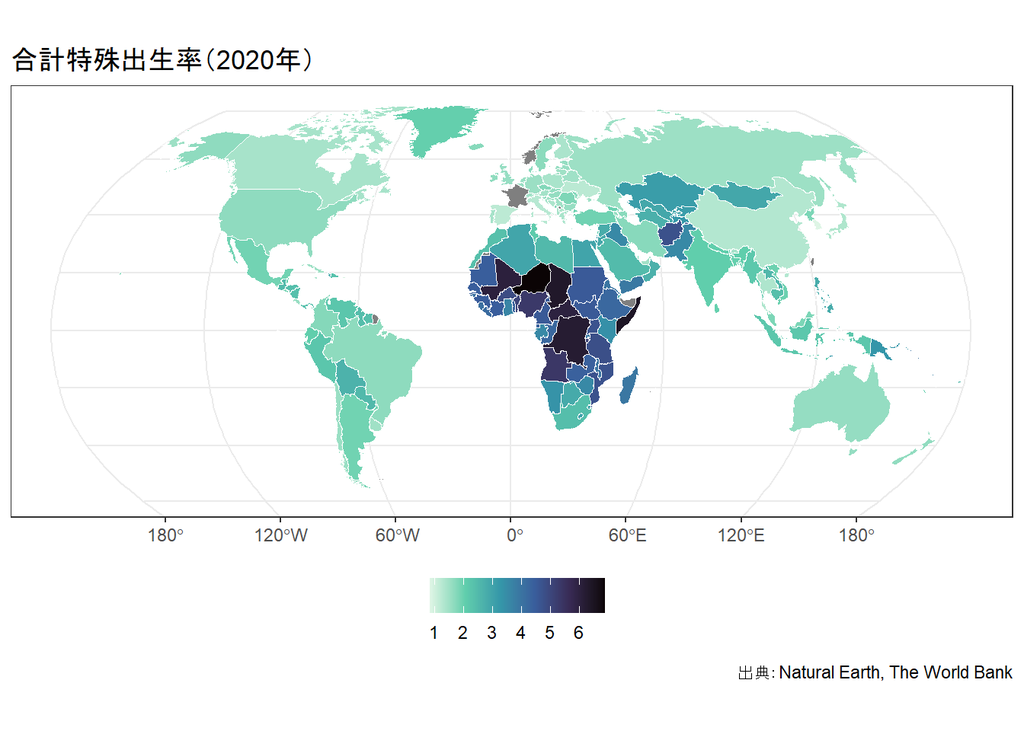

# 応用

## 南アメリカ州の平均寿命

**南アメリカ州の選抜**

世界地図から南アメリカ州に属する国を切り抜く（`filter()`）．

```r
Life_ex_map %>%
  filter(continent=="South America") ->
  SA_Life_ex_map
```

**南アメリカ州地図**

国名（英字2桁の国名コード`iso_a2`）を記した地図を作成する．

- コードは省略．

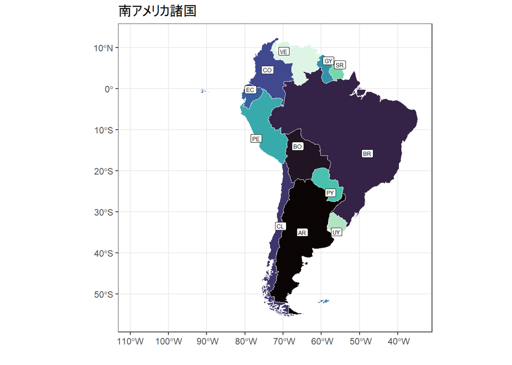

**完成図形**

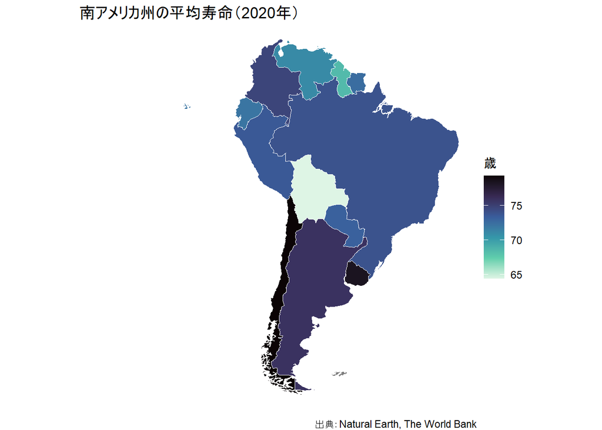

```r
ggplot()+
  geom_sf(data=SA_Life_ex_map, aes(fill=life_ex),
          color="white")+
  scale_fill_viridis_c(option="G", direction=-1)+
  labs(fill="歳",
       caption="出典：Natural Earth, The World Bank")+
  ggtitle("南アメリカ州の平均寿命（2020年）")+
  theme_void()
```

## 南アメリカ州の出生率

コードは繰り返しのため省略．

**完成図形**

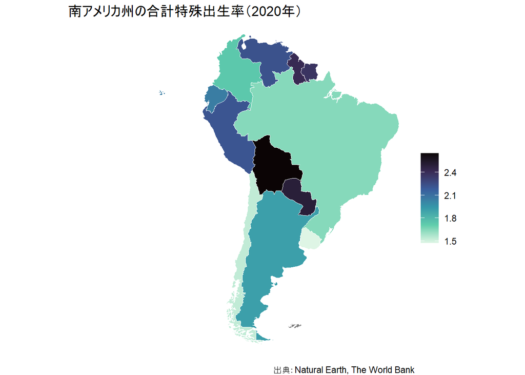

**参考ウェブサイト**

[Introduction to mapping in R](https://medium.com/analytics-vidhya/mapping-australia-in-r-6ce092c48b49)（アクセス日：2022-08-15）

[How to Download World Bank Data in R-Studio](https://www.youtube.com/watch?v=R9qw_k94wK0)（アクセス日：2022-08-15）← YouTube動画

**Rによる地理空間データの可視化**

- チュートリアル[ホーム](https://shinichiro-iwata.github.io/geospatial-data-visualization/)

**アイコン**

[Font Awesome](https://fontawesome.com/) 6.7.2